# Tölvuverkefni 3

Líkindareikningur og tölfræði: STÆ203G, HAG206G, MAS201F

## Þið eigið að vinna verkefnið í `.Rmd` skrá en skila `.html` skrá (LaTeX fólk má vinna í `.Rnw` skrá og skila `.pdf` skrá).

## EKKI verður tekið við lausnum á öðru formi en .html eða .pdf (ekki skila .Rmd, .zip, .txt, .docx, o.s.fr.)

#### ATHUGIÐ `.html` skráin verður til í sömu möppu og `.Rmd` skráin þegar þið prjónið.

### Þið megið vinna verkefnið tvö og tvö saman en ekki í stærri hópum.

## Merkja þarf lausnir með **nafni og HÍ-notendanafni** þeirra sem unnu verkefnið.

## Hlaða skal `.html` eða `.pdf` skrá inn á Uglu ekki síðar en þriðjudaginn 2. apríl klukkan 23:59.

### EKKI verður tekið við lausnum sem skila sér síðar.

### Frágangur gildir 10% af einkunn fyrir verkefnið (merkja verkefni með nafni og notendanafni, merkingar á ásum, töflur, uppsetning, …).

### Til að búa til fagrar töflur mælum við með að þið notið `kable()` fallið en hana má finna í `knitr` pakkanum (munið að keyra `library()` skipun).

### Meiri krafa verður gerð til frágangs í þetta skiptið, svo sem til útlits á töflum.

# Verkefnislýsing

Í þessu verkefni munið þið munið vinna með annað gagnasafn en í Tölvuverkefni 1 og 2 en þetta gagnasafn inniheldur mælingar á fiskum í “togararalli” Hafrannsóknastofnunarinnar 1998. Gagnasafnið inniheldur eftirfarandi dálka:

```
recid      Færslunúmer
reit       Tilkynningaskyldureitur
smrt       Smáreitur (undirreitir)
tog_nr   Númer togsins (innan reits)
dag      Dagur (innan mánaðar)
man      Mánuður
dyp_min  Minnsta dýpi í toginu
dyp_max  Mesta dýpi í toginu
vf       Veiðarfæri (á alltaf að vera það sama hér)
nr       Númer fisks í sýninu
le       Lengd fisksins
ky       Kyn fisksins (1=hængur)
kt       Kynþroski (1=ókynþroska, 4=hrygndur)
aldur    Aldur fisksins
osl      Óslægð þyngd (lifandi vigt)
sl       Slægð þyngd
li       Þyngd lifrarinnar
```

Reitum má breyta í lengdar- og breiddargráður: Tilkynningaskyldureitur https://www.rdocumentation.org/packages/geo/versions/1.4-3/topics/rect2deg

Það er skynsamlegt að byrja á að líta á hverja breytu fyrir sig, t.d. með því að gera stuðlarit eða stöplarit og fá þannig tilfinningu fyrir gögnunum, Það er einnig sniðugt að hugleiða hvort vænlegra sé að líta á `aldur` sem strjála eða samfellda breytu.

Gagnaskráin sem þið eigið að vinna með er í Uglu (úr möppunni R-tölvuverkefni) en hana er einnig að finna hér:

https://notendur.hi.is/~gunnar/LikTol/data98.csv

Þið getið leitað með Hr. Google að “tilkynningaskyldureitir” eða notað eftirfarandi til að sjá hvar reitirnir liggja

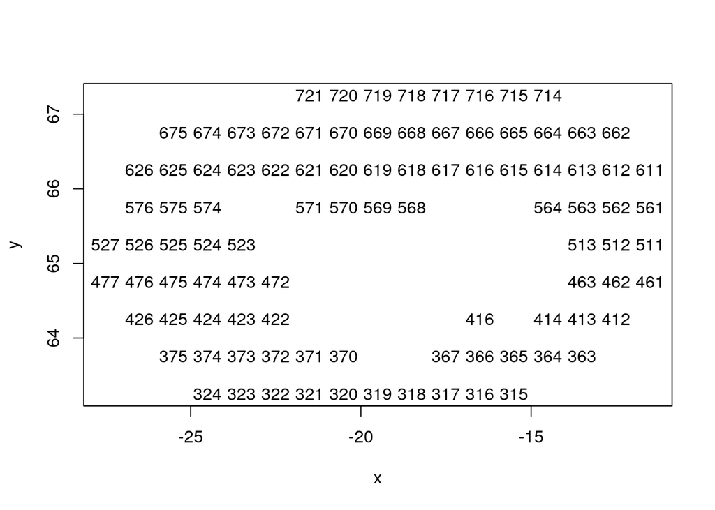

```r
r2d <-function(r)
{
    lat <- floor(r/100)
    lon <- (r - lat * 100) %% 50
    halfb <- (r - 100 * lat - lon)/100
    lon <-  - (lon + 0.5)
    lat <- lat + 60 + halfb + 0.25
    data.frame(lat = lat, lon = lon)
}
gs<-read.csv("http://hi.is/~gunnar/LikTol/data98.csv")
reitir<-unique(gs$reit)
x<-r2d(reitir)$lon
y<-r2d(reitir)$lat
plot(x,y,type='n')
text(x,y,as.character(reitir))
```

(athugið að þetta er EKKI besta leiðin til að teikna þessa mynd - sjá bónusspurninguna).

#### a) (5%)

Lesið gagnaskrána inn með `read.csv()` skipuninni og geymið í hlut (gagnaramma) sem ber upphafsstafi þeirra sem verkefnið vinna (ef Gréta Halldórsdóttir og Sigurður Jónsson eru að vinna saman skulu þau nefna hlutinn gs en ef Atli Pétursson er að vinna einn skal hann nefna hlutinn sinn ap).

Það á ekki að vanta gildi (missing values) í gagnaskránni.

Athugið að öll gildin í töflunni eru tölur. Sumt er betur gert að þáttum (flokkabreytur, factors), en það má gera á seinni stigum.

**Búið til nýja breytu sem inniheldur hafsvæði.**

Skýrið nýju breytuna `hafsvaedi`. Nýja breytan á að verða hluti af gagnatöflunni ykkar.

Hafsvæðisbreytuna á að skilgreina með flokkunum SV, NV, NA, SA. Skipting flokkanna er eftirfarandi:

- S-N skiptingin er um breiddarbaug 65 gráður norðlægrar breiddar (þ.e. 65, svo reitir 527, 561 lenda til norðurs)
- A-V skiptingin um lengdarbaug 19 gráður vestlægrar lengdar (þ.e. -19 svo reitir 319, 569 lenda til vesturs).

Breytan ykkar, `hafsvaedi`, verður flokkabreyta með fjórum flokkum.

**Búið til nýja kynþroskabreytu, `kt2`, sem inniheldur einungis tvo flokka: kynþroska og ókynþroska.**

**Nýja kynþroskabreytan, `kt2`, er háð gömlu kynþroskabreytunni, `kt`, á eftirfarandi hátt:**

Kynþroskabreytan í gögnunum, `kt`, inniheldur flokkana

- 1 = Ókynþroska
- 4 = Hryngdur (stig kynþroska fisks)
- 2,3,5,22 = Önnur stig kynþroska fisks

Æviskeið fiska samanstendur af nokkrum mismunandi stigum kynþroska. Annars vegar er fiskur ókynþroska eða á einhverju stigi kynþroskans. Fiskur sem er á einhverju stigi kynþroskans flokkast sem kynþroska fiskur.

Hér eftir vinnum við með kynþroskabreytuna með þessum tveimur flokkum.

#### b) (12%)

Sýnið í töflu hversu margir fiskar af hvoru kynþroskastigi veiddust á hverju hafsvæði.

Búið til aðra töflu sem sýnir kynþroskahlutfallið á hverju hafsvæði (það á t.d. að vera hægt að lesa hversu hátt hlutfall fiska á suð-vestursvæði (SV) séu kynþroska og ókynþroska).

Teiknið mynd sem er lýsandi fyrir fjölda fiska af hvoru kynþroskastigi í hverjum flokki af hafsvæðunum fjórum.

#### c) (12%)

Sýnið í töflu fjölda fiska, meðallengd, meðalþyngd og staðalfrávik lengdar eftir aldri. Lýsið í örstuttu máli niðurstöðum ykkar sem sjá má í töflunni.

Teiknið eftirfarandi tvær myndir:

- Mynd sem sýnir **lengd** fiska eftir aldri þegar litið er á aldur sem **samfellda** breytu ásamt **meðallengd** fiska fyrir hvern aldurshóp sem stærri rauða punkta
- Kassarit sem sýnir **lengd** fiska eftir aldri þegar litið er á aldur sem **strjála** breytu

Eru einhverjir útlagar í aldurshópunum?

Hverjir eru kostirnir við hvora framsetningu fyrir sig?

#### d) (5%)

Veljið nú tvö hafsvæði af handahófi með `sample()` fallinu eftir að hafa keyrt `set.seed()` með afmælisdeginum ykkar eins og í verkefni 2.

Veljið af handahófi 50 fiska af hvoru hafsvæði. Til að velja fiskana er gott að nota `sample_n()` fallið úr `dplyr` pakkanum því það velur raðir úr gagnaramma af handahófi svo að þið fáið nýjan gagnaramma fyrir hvort hafsvæði (það má líka nota `sample()`). Munið að keyra `set.seed()` með afmælisdeginum ykkar áður en þið keyrið hvora `sample_n()` skipunina fyrir sig.

Sameinið fiskana 100 í eina gagnatöflu (gagnaramma). Gott er að nota `rbind()` fallið til að sameina gagnarammana.

#### e) (15%)

Kannið með viðeigandi tilgátuprófi, með 95% marktæknikröfu, hvort munur sé á meðallengd fiska á hafsvæðunum tveimur.

Setjið fram tilgáturnar á formlegan hátt ($H_0$ og $H_1$).

Hvaða forsendur þurfa gögnin að uppfylla til þess að eiga von á því að tilgátuprófið gefi heilvita niðurstöðu?

Tilgreinið gildið á prófstærðinni ásamt p-gildinu í samfelldu máli og segið í örfáum orðum hvaða ályktun þið dragið.

Sýnið einnig 95%-öryggisbil fyrir mismun meðaltalanna á hafsvæðunum tveimur. Inniheldur öryggisbilið 0? Hvers vegna eða hvers vegna ekki?

MUNIÐ: “Samfellt mál” þýðir TEXTI sem samanstendur af heilsteyptum setningum með sögnum (sagnorðum) og nafnorðum. Það er ekki átt við blokkir af úttaki úr R!

#### f) (12%)

**Teiknið stuðlarit** af lengd fyrir hvert hafsvæði með því að nota allar lengdarmælingar úr upphaflega gagnasafninu.

**Teiknið inn á stuðlaritin í rauðum lit** þéttleikafall (graf) þeirrar normaldreifingar sem “náttúrulegt” (eðlilegt) væri að búast við að gögnin fyrir hvert hafsvæði fylgdu.

Notið `binwidth = 3` fyrir stuðlaritin.

Best er að teikna myndirnar fjórar ásamt þéttleikaföllum á eftirfarandi hátt:

- Búum til gagnaramma á löngu sniði (long format) sem inniheldur flokkabreytuna `hafsvaedi` og lengdarbreytuna `le`

```r
library(reshape2)
gs.long = melt(gs, id.vars='hafsvaedi', measure.vars='le', value.name='le')
```

- Hermum gögn úr “náttúrulegu” normaldreifingunni fyrir hvert hafsvæði

```r
# Skilgreinum fall sem ad tekur inn gagnavigur x og
#   skilar gognum sem fylgja "natturulegu" normaldreifingu vigursins x
get_normal_density <- function(x, binwidth) {
  grid <- seq(min(x), max(x), length=100)
  data.frame(
    le = grid,
    normal_curve = dnorm(grid, mean(x), sd(x)) * length(x) * binwidth
  )
}

# Skilgreinum breytu fyrir binwidth
BW <- 3

# Buum til normaldreifd gogn fyrir hvert hafsvaedi med thvi ad
#   beita fallinu "get_normal_density" a lengdarmaelingar sem tilheyra
#   hverju hafsvaedi fyrir sig
normaldens <-
  gs %>%
  group_by(hafsvaedi) %>%
  do(get_normal_density(x=.$le, binwidth=BW))
```

- Þið þurfið nú að skrifa kóðann til þess að teikna myndirnar fjórar upp, notið `facets()` fallið líkt og í verkefni 2 og nýtið ykkur `geom_line()` fallið úr `ggplot2` pakkanum ásamt normaldreifðu gögnunum sem þið búið til líkt og sýnt er fyrir ofan til þess að teikna þéttleikaföllin (gröfin) inn á myndirnar

Túlkið það sem myndirnar sýna. Fylgja gögnin normaldreifingu?

#### g) (5%)

Munið að ein forsendan fyrir því að mega nota t-prófið eins og gert var, er að gögnin séu normaldreifð. Til eru fjölmörg önnur próf en t-próf sem ekki krefjast normaldreifingar. Eitt slíkt er slembivalspróf (randomization test eða permutation test).

Þá eru öll gögnin (lengdirnar sem fóru inn í að reikna prófstærðina fyrir t-prófið) úr gagnasöfnunum tveimur (hafsvæðin tvö sem unnið var með í liðunum á undan) sett saman, dregið slembið úr samsetta gagnasafninu án skila og skipt aftur í tvö gagnasöfn af sömu stærðum (sami fjöldi gagnapunkta) og upphaflegu gagnasöfnin voru, nýtt t-gildi reiknað og svo talið hve oft nýja t-gildið er tölulega stærra en upphaflega t-gildið (sem þið reiknuðuð í venjulega t-prófinu).

P-gildi prófsins er hlutfall þeirra skipta sem nýja t-gildið er tölulega stærra en upphaflega t-gildið.

**Framkvæmið slembivalsprófið fyrir ykkar t-próf:**

Segjum að þið hafið vistað prófstærð upphaflega t-prófsins í breytunni `t0`.

Þá getið þið borið tölugildið af, `t0`, saman við tölugildið af `t.test(z[sample(1:length(z))]~xyind)$statistic` þar sem `xyind` er vigur af sömu lengd og samsetta gagnasafnið sem er geymt í breytunni `z`.

Vigurinn `xyind` inniheldur gildin 1 og 2 og er notaður til þess að skipta gögnunum í tvö gagnasett af sömu stærðum og upprunalegu gagnasöfnin (fyrir hvort hafsvæði) sem unnið var með í liðunum á undan.

Endurtakið þetta 5000 sinnum með því að nota `replicate()` fallið eins og í fyrri verkefnum.

Setjið p-gildið fram ásamt ásamt þeirri ályktun sem þið dragið (í samfelldu máli). Er ályktunin í samræmi við ályktunina sem þið dróguð af venjulega t-prófinu?

#### h) (15%)

Kannið með viðeigandi tilgátuprófi, með 95% marktæknikröfu, hvort munur sé á hlutfalli kynþroska fiska á hafsvæðunum tveimur. Athugið að þið gætuð þurft að henda úr hafsvæðisgögnunum ykkar ónotuðum flokkum í flokkabreytunni `hafsvaedi`. Þið getið gert það með `droplevels()` fallinu

Birtið töflu yfir fjölda kynþroska og ókynþroska fiska á hvoru hafsvæði.

Setjið tilgáturnar fram á formlegan hátt ($H_0$ og $H_1$). Tilgreinið gildið á prófstærðinni, p-gildinu og matið á stikunum sem verið er að prófa í samfelldu máli. Takið fram hvort að matið á stikunum sé fyrir hlutfall kynþroska fiska eða ókynþroska fiska.

Segið í örfáum orðum hvaða ályktun þið dragið.

Sýnið einnig 95%-öryggisbil fyrir mismun hlutfallanna. Inniheldur öryggisbilið 0? Hvers vegna eða hvers vegna ekki?

#### i) (12%)

Veljið annað hvort hafsvæðið sem þið unnuð með í liðunum hér að framan (þið eigið að vera með 50 fiska). Þið getið notað beint annan gagnaramman sem þið bjugguð til í lið d) eða notað `filter()` á sameinaða gagnarammann ykkar.

Teiknið mynd sem sýnir sambandið á milli lengdar og þyngdar fiskanna (þyngd er spábreytan).

Teiknið mynd sem sýnir sambandið á milli lograns af lengd og lograns af þyngd fiskanna (þyngd er spábreytan).

Smíðið aðhvarfsgreiningarlíkan sem nota má til að spá fyrir um þyngd út frá lengd. Geymið líkanið í breytunni `fit`. Athugið að hér er eðlilegast að nota logrann af báðum breytum (hvers vegna? - þið þurfið að útskýra þetta).

Setjið líkanið fram ásamt mati á stikum þess.

Segið með örfáum orðum hvort þið teljið skynsamlegt að nota líkan sem þetta til að spá fyrir um þyngd út frá lengd fiskanna.

#### j) (4%)

Teiknið aftur mynd, líkt og í lið i), sem sýnir sambandið á milli lengdar og þyngdar fiskanna (þyngd er spábreytan eða óháða breytan). En í þetta sinn eigið þið að teikna inn á myndina bestu beinu línu ásamt bestu línu sem líkanið sem þið smíðuðuð í lið i) gefur. Teiknið bestu línu líkansins í rauðu.

Í `ggplot` pakkanum er fall sem að teiknar bestu beinu línu í gegnum gögnin sjálfkrafa fyrir ykkur: `stat_smooth(method='lm', se=FALSE)`.

Einfaldasta leiðin til þess að teikna bestu línu líkansins er að búa til nýjan gagnaramma sem að inniheldur spábreytugildin úr líkaninu og gildi spáðu breytunnar (háðu breytunnar) úr líkaninu. Þetta má gera á eftirfarandi hátt

```r
gogn_likan <-
  data.frame(
    x = ?(fit$model[['X']]),
    y = ?(predict(fit))
  )
```

þar sem að þið þurfið að skipta `?` út fyrir fall sem að varpar gögnunum aftur á raunskala (líkanið var búið til á lograskala) og `X` út fyrir heiti x-breytunnar í líkaninu.

Þið getið svo notað `ggplot` fallið `geom_line()` til þess að teikna bestu línu líkansins. Athugið að þar sem að líkanið var búið til á gögnum á lograskala þá er eðlilegt að besta lína þess sé EKKI bein þegar búið er að varpa aftur yfir á raunskala.

#### k) (3%)

Hér er áfram unnið með hafsvæðið sem var valið í liðnum á undan.

Beinar línur eru oft ekki rétt líkan.

Teiknið fyrst lengd á móti aldri fyrir ykkar hafsvæði, sem kassarit.

Leggið beina línu í gegnum gögnin, síðan frjálst líkan með aldurinn sem flokkabreytu og berið þau saman:

```r
litid <- lm(le~aldur, data=gs)
stort <- lm(le~factor(aldur), data=gs)
anova(litid, stort)
```

Munið að nota ykkar eigin gögn en ekki `data=gs`.

Bæði líkönin heita línuleg líkön því þau eru línuleg í stikum sínum. Hins vegar lýsir síðara sambandið alls ekki beinni línu milli `le` og `aldur`.

Túlkið niðurstöðuna, bæði myndina og prófið, sem `anova` skipunin gerði fyrir ykkur.

Þið getið gert þetta sem formlegt tilgátupróf eða í orðum, en þurfið að lágmarki að túlka bæði myndina og síðustu töluna í töflunni.

#### Bónusspurning (10%):

Finnið sjálf, hvernig má teikna rétt lengdar- og breiddarbauga ásamt útlínum landsins og afmarkið á myndinni svæðin sem þið hafið valið, helst með tilkynningaskyldureitum. Athugið að til þess þarf að nota skynsamlega vörpun o.s.frv.

Þið getið byrjað með þetta, en þetta er alls ekki nóg:

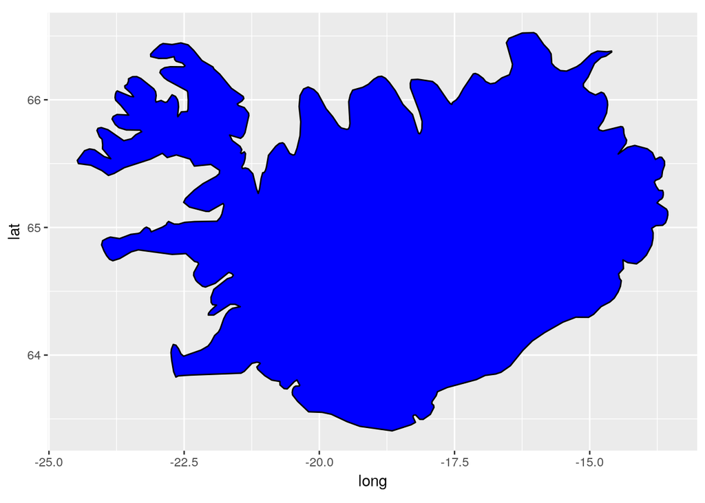